# Beltrame_Ginevra_Rlab03

2024-05-23

## Exercise 1: Bayesian Inference for Poisson model

The number of particles emitted by a radioactive source during a fixed interval of time (∆t = 10 s) follows a Poisson distribution on the parameter µ. The number of particles observed during consecutive time intervals is: 4, 1, 3, 1, 5 and 3.

1. assuming a positive uniform prior distribution for the parameter µ:
   - determine and draw the posterior distribution for µ, given the data
   - evaluate mean, median and variance, both analytically and numerically in R
2. assuming a Gamma prior such that the expected value is µ = 3 with a standard deviation σ = 1,
   - determine and draw the posterior distribution for µ, given the data
   - evaluate mean, median and variance, both analytically and numerically in R.
3. evaluate a 95% credibility interval for the results obtained with different priors. Compare the result with that obtained using a normal approximation for the posterior distribution, with the same mean and standard deviation

### Solution

#### (a) Uniform prior

Assuming a Uniform prior on a Poisson process signifies that the distribution of the parameter $\mu$ follows the constant function $g(\mu) = 1$. This means that the posterior is of the form $Gamma(α, λ)$, with $α = \sum{y_j} + 1$ and $λ = n$.

From the given experimental data we know that $n=6$ and $\{y_j\}_{j=1...n} = \{4, 1, 3, 1, 5, 3\}$. Therefore we obtain

$$Gamma(α, λ) = Gamma(18, 6)$$

We can finally draw the posterior distribution.

```r
y_i <- c(4, 1, 3, 1, 5, 3)
alpha_u <- sum(y_i) + 1
lambda_u <- length(y_i)

x <- seq(0, 10, length.out = 100)
y_u <- dgamma(x, shape = alpha_u, rate = lambda_u)
data_u <- data.frame(x = x, y = y_u)
```

As for the mean, variance and median of the distribution, they can be derived both analytically and numerically with R. Specifically, the analytic form of the $Gamma$ pdf is the following

$$f(x) = \frac{1}{\Gamma(\alpha)} x^{\alpha-1} \lambda^{\alpha}
e^{-\lambda x}$$

We can therefore derive the mean and variance in a closed form by integration.

$$E[X] = \int_{0}^{\infty} xf(x) \, dx =
\frac{\lambda^\alpha}{\Gamma(\alpha)} \int_{0}^{\infty} x^\alpha
e^{-\lambda x} \, dx \\
E[X^2] = \int_{0}^{\infty} x^2 f(x) \, dx =
\frac{\lambda^\alpha}{\Gamma(\alpha)} \int_{0}^{\infty} x^{\alpha+1}
e^{-\lambda x} \, dx$$

These can be solved by applying the substitution $u=\lambda x$, hence $dx=\frac{du}{\lambda}$:

$$E[X] = \frac{\lambda^\alpha}{\Gamma(\alpha)} \int_{0}^{\infty}
(\frac{u}{\lambda})^\alpha e^{-u} \, \frac{du}{\lambda} =
\frac{1}{\Gamma(\alpha) \lambda} \int_{0}^{\infty} u^\alpha e^{-u} \, du
= \frac{\Gamma(\alpha+1)}{\Gamma(\alpha) \lambda} =
\frac{\alpha}{\lambda}\\
E[X^2] = \frac{\lambda^\alpha}{\Gamma(\alpha)} \int_{0}^{\infty}
(\frac{u}{\lambda})^{\alpha+1} e^{-u} \, \frac{du}{\lambda} =
\frac{1}{\Gamma(\alpha) \lambda^2} \int_{0}^{\infty} u^{\alpha+1} e^{-u}
\, du = \frac{\Gamma(\alpha+2)}{\Gamma(\alpha) \lambda^2} =
\frac{\alpha(\alpha+1)}{\lambda^2}$$

Thus

$$E[X] = \frac{\alpha}{\lambda} = \frac{18}{6} = 3\\
Var(X) = E[X^2] - E[X]^2 = \frac{\alpha(\alpha+1)}{\lambda^2} -
\frac{\alpha^2}{\lambda^2} = \frac{\alpha}{\lambda^2} = \frac{18}{36} =
0.5$$

As for the median, it cannot be calculated analytically, although it can be said that for large values of the shape parameter $α$, the Gamma distribution approximates the normal distribution and the median is therefore approximated by the mean $\frac{\alpha}{\lambda}$.

We compute now the same results in a numerical fashion, using R.

```r
# Define shape and rate parameters
shape <- alpha_u
rate <- lambda_u

# I calculate the median of the Gamma distribution with a quantile function
median_unif <- qgamma(0.5, shape = shape, rate = rate)
# and the mean and variance with a numerical simulation
set.seed(123)
samples <- rgamma(10000, shape, rate)

mean_unif <- mean(samples)
variance_unif <- var(samples)

cat("Estimated Mean:", mean_unif, "\n")
```

```
## Estimated Mean: 2.986196
```

```r
cat("Estimated Variance:", variance_unif, "\n")
```

```
## Estimated Variance: 0.4923694
```

```r
cat("Estimated Median:", median_unif, "\n")
```

```
## Estimated Median: 2.944631
```

It can be observed that these results are quite similar to the analytical ones.

#### (b) Gamma prior

We assume now a Gamma prior, such that the expected value is $\mu = 3$ with a standard deviation is $σ = 1$. Based on the previous analytical results on the Gamma distribution, we can determine the shape and rate (or scale) parameters.

$$\mu = \frac{\alpha}{\lambda} \qquad \text{and} \qquad \sigma^2 =
\frac{\alpha}{\lambda^2} \\
\text{therefore} \qquad \lambda = \frac{\mu}{\sigma^2} = 3 \qquad
\text{and} \qquad \alpha = \frac{\mu^2}{\sigma^2} = 9$$

The prior is then the function $Gamma(9,3)$, resulting in a posterior of the form $Gamma(\alpha',\lambda')$ with $α' = α + \sum{y_j} = 9 + 17 = 26$ and $λ'= λ + n = 3 + 6 = 9$. So

$$Gamma(α, λ) = Gamma(26, 9)$$

and we can draw the posterior distribution.

```r
y_i <- c(4, 1, 3, 1, 5, 3)
mu <- 3
sigma <- 1
alpha_g <- mu^2/sigma^2 + sum(y_i)
lambda_g <- mu/sigma^2 + length(y_i)

y_g <- dgamma(x, shape = alpha_g, rate = lambda_g)
data_g <- data.frame(x = x, y = y_g)
```

It follows that the mean, variance and median can be determined analytically as

$$E[X] = \frac{\alpha}{\lambda} = \frac{26}{9} \approx 2.89\\
Var(X) = E[X^2] - E[X]^2 = \frac{\alpha(\alpha+1)}{\lambda^2} -
\frac{\alpha^2}{\lambda^2} = \frac{\alpha}{\lambda^2} = \frac{26}{81}
\approx 0.32 \\
Median(X) \approx E[X] \approx 2.89$$

and numerically as

```r
# Define shape and rate parameters
shape <- alpha_g
rate <- lambda_g

# I calculate the median of the Gamma distribution with a quantile function
median_gamma <- qgamma(0.5, shape = shape, rate = rate)
# and the mean and variance with a numerical simulation
set.seed(123)
samples <- rgamma(10000, shape, rate)

mean_gamma <- mean(samples)
variance_gamma <- var(samples)

cat("Estimated Mean:", mean_gamma, "\n")
```

```
## Estimated Mean: 2.879461
```

```r
cat("Estimated Variance:", variance_gamma, "\n")
```

```
## Estimated Variance: 0.3149574
```

```r
cat("Estimated Median:", median_gamma, "\n")
```

```
## Estimated Median: 2.851937
```

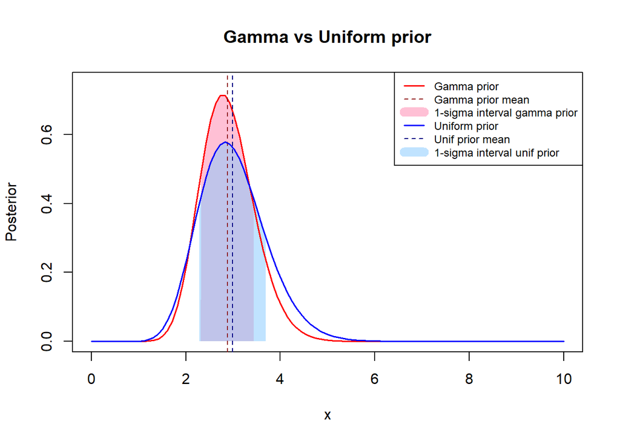

```r
plot(data_g$x, data_g$y, type = "l", main='Gamma vs Uniform prior', ylim=c(0, 0.75), xlim=c(0, 10), lty=1, lwd=1.5, col='white', xlab='x', ylab='Posterior')

x_red_g <- data_g$x[data_g$x >= mean_gamma - sqrt(variance_gamma) & data_g$x <= mean_gamma + sqrt(variance_gamma)]
y_red_g <- data_g$y[data_g$x >= mean_gamma - sqrt(variance_gamma) & data_g$x <= mean_gamma + sqrt(variance_gamma)]
polygon(c(mean_gamma - sqrt(variance_gamma), mean_gamma - sqrt(variance_gamma), x_red_g, mean_gamma + sqrt(variance_gamma), mean_gamma + sqrt(variance_gamma)), c(0, 0.12, y_red_g, 0.09, 0), col = rgb(255/255, 130/255, 171/255, 0.5), border = NA)

x_red_u <- data_u$x[data_u$x >= mean_unif - sqrt(variance_unif) & data_u$x <= mean_unif + sqrt(variance_unif)]
y_red_u <- data_u$y[data_u$x >= mean_unif - sqrt(variance_unif) & data_u$x <= mean_unif + sqrt(variance_unif)]
polygon(c(mean_unif - sqrt(variance_unif), mean_unif - sqrt(variance_unif), x_red_u, mean_unif + sqrt(variance_unif), mean_unif + sqrt(variance_unif)), c(0, 0.38, y_red_u, 0.3, 0), col = rgb(130/255, 200/255, 255/255, 0.5), border = NA)


lines(data_g$x, data_g$y, lty=1, lwd=1.5, col='red')
abline(v=mean_gamma, col='darkred', lwd=1, lty=2)
lines(data_u$x, data_u$y, col='blue', lwd=1.5, lty=1)
abline(v=mean_unif, col='navy', lwd=1, lty=2)

leg.colors <- c('red', 'darkred', rgb(255/255, 130/255, 171/255, 0.5), 'blue', 'navy', rgb(130/255, 200/255, 255/255, 0.5))
leg.labels <- c('Gamma prior', 'Gamma prior mean', '1-sigma interval gamma prior', 'Uniform prior', 'Unif prior mean', '1-sigma interval unif prior')
leg.ltypes <- c(1, 2, 1, 1, 2, 1)
leg.lwidths <- c(1.5, 1, 10, 1.5, 1, 10)
legend("topright", legend=leg.labels, lty=leg.ltypes, col=leg.colors, lwd=leg.lwidths, cex=0.75)
```

#### (c) 95% credibility intervals

```r
cf <- 0.975

y_ng <- dnorm(x, mean_gamma, sqrt(variance_gamma))
data_ng <- data.frame(x = x, y = y_ng, group='normal from gamma')

y_nu <- dnorm(x, mean_unif, sqrt(variance_unif))
data_nu <- data.frame(x = x, y = y_nu, group='normal from unif')

cf_g <- qgamma(c(1-cf, cf), alpha_g, lambda_g)
cf_u <- qgamma(c(1-cf, cf), alpha_u, lambda_u)
cf_ng <- qnorm(c(1-cf, cf), mean = mean_gamma, sd = sqrt(variance_gamma))
cf_nu <- qnorm(c(1-cf, cf), mean = mean_unif, sd = sqrt(variance_unif))

cat("95% CREDIBILITY INTERVALS\n")
```

```
## 95% CREDIBILITY INTERVALS
```

```r
cat("Gamma distribution - uniform prior case: [", cf_u[1], ",", cf_u[2], "]\n")
```

```
## Gamma distribution - uniform prior case: [ 1.77799 , 4.536441 ]
```

```r
cat("Normal distribution - uniform prior case: [", cf_nu[1], ",", cf_nu[2], "]\n")
```

```
## Normal distribution - uniform prior case: [ 1.610908 , 4.361484 ]
```

```r
cat("Gamma distribution - gamma prior case: [", cf_g[1], ",", cf_g[2], "]\n")
```

```
## Gamma distribution - gamma prior case: [ 1.887118 , 4.100548 ]
```

```r
cat("Normal distribution - gamma prior case: [", cf_ng[1], ",", cf_ng[2], "]\n")
```

```
## Normal distribution - gamma prior case: [ 1.779508 , 3.979413 ]
```

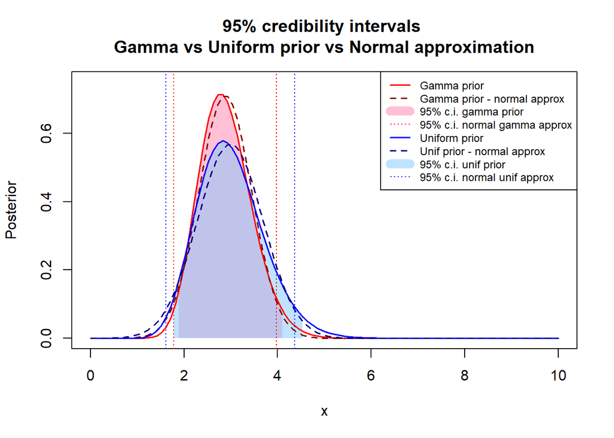

```r
plot(data_g$x, data_g$y, type = "l", main='95% credibility intervals \nGamma vs Uniform prior vs Normal approximation', ylim=c(0, 0.75), xlim=c(0, 10), lty=1, lwd=1.5, col='white', xlab='x', ylab='Posterior')

x_red_g <- data_g$x[data_g$x >= cf_g[1] & data_g$x <= cf_g[2]]
y_red_g <- data_g$y[data_g$x >= cf_g[1] & data_g$x <= cf_g[2]]
polygon(c(cf_g[1], cf_g[1], x_red_g, cf_g[2], cf_g[2]), c(0, 0.12, y_red_g, 0.09, 0), col = rgb(255/255, 130/255, 171/255, 0.5), border = NA)

x_red_u <- data_u$x[data_u$x >= cf_u[1] & data_u$x <= cf_u[2]]
y_red_u <- data_u$y[data_u$x >= cf_u[1] & data_u$x <= cf_u[2]]
polygon(c(cf_u[1], cf_u[1], x_red_u, cf_u[2], cf_u[2]), c(0, 0.08, y_red_u, 0.06, 0), col = rgb(130/255, 200/255, 255/255, 0.5), border = NA)


lines(data_g$x, data_g$y, lty=1, lwd=1.5, col='red')
lines(data_ng$x, data_ng$y, lty=2, lwd=1.5, col='darkred')
abline(v=c(cf_ng[1], cf_ng[2]), col='red', lwd=1, lty=3)
lines(data_u$x, data_u$y, col='blue', lwd=1.5, lty=1)
lines(data_nu$x, data_nu$y, lty=2, lwd=1.5, col='navy')
abline(v=c(cf_nu[1], cf_nu[2]), col='blue', lwd=1, lty=3)

leg.colors <- c('red', 'darkred', rgb(255/255, 130/255, 171/255, 0.5), 'red', 'blue', 'navy', rgb(130/255, 200/255, 255/255, 0.5), 'blue')
leg.labels <- c('Gamma prior', 'Gamma prior - normal approx', '95% c.i. gamma prior', '95% c.i. normal gamma approx', 'Uniform prior', 'Unif prior - normal approx', '95% c.i. unif prior', '95% c.i. normal unif approx')
leg.ltypes <- c(1, 2, 1, 3, 1, 2, 1, 3)
leg.lwidths <- c(1.5, 1.5, 10, 1, 1.5, 1.5, 10, 1)
legend("topright", legend=leg.labels, lty=leg.ltypes, col=leg.colors, lwd=leg.lwidths, cex=0.75)
```

## Exercise 2: Efficiency using Bayesian approach

Assuming a binomial model where $n$ is the number of trials and $r$ is the number of success out of $n$ trials,

1. Evaluate the mean and the variance using a Bayesian approach under the hypothesis of:
   - uniform prior ∼ $U(0, 1)$
   - Jeffrey’s prior ∼ $Beta(1/2, 1/2)$
2. Plot the posterior distributions for both cases

Taking into account that the same detector has been studied by researcher B, who has performed only $n = 10$ measurements and has obtained $r = 10$ signals,

3. Evaluate the mean, the variance and the posterior distribution using a uniform prior with the results of researcher B.
4. Repeat the computation of points a) and b) with the data of researcher A using as a prior the posterior obtained from point c).
5. [Optional] Compute 95% credible interval using the posterior of the previous point d).

### Solution

#### (a, b) Mean, variance and posterior distributions of researcher A

It is assumed that the events follow a binomial distribution, in the form of

$$Bn(x|p,n) = \binom{n}{x} p^x (1-p)^{n-x}$$

where the probability of success $p = \frac{r}{n} = 0.624$ is computed from the experimental data. This expression gives the probability of $x$ successes in $n$ independent Bernoulli trials. We also adopt, alternatively, a uniform prior and Jeffrey’s prior.

##### Uniform prior

The prior is in this case $P(\pi|H) \thicksim U(0,1) = Beta(1,1)$, so that the posterior pdf is proportional to the likelihood.

It can be inferred in this case that the mean and variance are calculated from

$$E[\pi] = \int_{0}^{1} \pi P(\pi | r,n,H) d\pi = \frac{1}{Z} \int_{0}^{1}
\pi^{r+1} (1-\pi)^{n-r} d\pi \\
E[\pi^2] = \int_{0}^{1} \pi^2 P(\pi | r,n,H) d\pi = \frac{1}{Z}
\int_{0}^{1} \pi^{r+2} (1-\pi)^{n-r} d\pi \\
\text{with the normalization factor} \quad Z = \int_{0}^{1} \pi^{r}
(1-\pi)^{n-r} d\pi \quad \text{and with} \quad n=500, r=312, \quad
Var(\pi) = E[\pi^2] - E[\pi]^2$$

These integrals can be calculated numerically or analytically by using the Beta and Gamma functions. Specifically, the Beta function is defined as $B(x,y) = \int_{0}^{1} t^{x-1} (1-t)^{y-1} dt = \frac{\Gamma(x) \Gamma(y)}{\Gamma(x+y)}$, so the previous expressions can be rewritten as follows.

$$E[\pi] = \frac{1}{Z} \int_{0}^{1} \pi^{(r+2)-1} (1-\pi)^{(n-r+1)-1} d\pi
= \frac{1}{Z} B(r+2,n-r+1) = \frac{1}{Z} \frac{\Gamma(r+2)
\Gamma(n-r+1)}{\Gamma(n+3)} \\
E[\pi^2] = \frac{1}{Z} \int_{0}^{1} \pi^{(r+3)-1} (1-\pi)^{(n-r+1)-1}
d\pi = \frac{1}{Z} B(r+3,n-r+1) = \frac{1}{Z} \frac{\Gamma(r+3)
\Gamma(n-r+1)}{\Gamma(n+4)} \\
Z = \int_{0}^{1} \pi^{(r+1)-1} (1-\pi)^{(n-r+1)-1} d\pi = B(r+1,n-r+1) =
\frac{\Gamma(r+1) \Gamma(n-r+1)}{\Gamma(n+2)}$$

it follows

$$E[\pi] = \frac{\Gamma(n+2)}{\Gamma(r+1) \Gamma(n-r+1)} \frac{\Gamma(r+2)
\Gamma(n-r+1)}{\Gamma(n+3)} = \frac{(n+1)!(r+1)!(n-r)!}{r!(n-r)!(n+2)!}
= \frac{r+1}{n+2} = \frac{313}{502} \approx 0.6235\\
E[\pi^2] = \frac{\Gamma(n+2)}{\Gamma(r+1) \Gamma(n-r+1)}
\frac{\Gamma(r+3) \Gamma(n-r+1)}{\Gamma(n+4)} =
\frac{(n+1)!(r+2)!(n-r)!}{r!(n-r)!(n+3)!} =
\frac{(r+2)(r+1)}{(n+3)(n+2)} = \frac{314 \cdot 313}{503 \cdot 502}
\approx 0.3892 \\
Var(\pi) \approx 0.3892 - 0.6235^2 \approx 0.0005$$

```r
n <- 500
r <- 312
n.sample <- 2000

plot_dist <- function(dist_function) {

  p <- seq(0, 1, 1/n.sample)
  posterior <- lapply(p, dist_function)

  y_values <- sapply(posterior, function(p) p$y)
  p.mean <- posterior[[1]]$mean
  p.variance <- posterior[[1]]$var

  p_red <- p[p >= p.mean - sqrt(p.variance) & p <= p.mean + sqrt(p.variance)]
  y_red <- y_values[p >= p.mean - sqrt(p.variance) & p <= p.mean + sqrt(p.variance)]

  plot(p, p, col='white', xlim=c(0,1), ylim=c(0, max(y_values)), xlab=expression(pi), ylab=expression(paste('P(', pi, '| r,n,H)')))
  polygon(c(p.mean - sqrt(p.variance), p.mean - sqrt(p.variance), p_red, p.mean + sqrt(p.variance), p.mean + sqrt(p.variance)), c(0, 0.38, y_red, 0.3, 0), col = rgb(130/255, 200/255, 255/255, 0.5), border = NA)

  lines(p, y_values, lwd=1.5, col='blue')

  abline(v=p.mean, lty=2)
  text(x = p.mean + 0.01, y = max(y_values) + 0.2, labels = expression(mu), col = "black", cex = 0.5)

  abline(v=p.mean - sqrt(p.variance) , lty=2, col='red')
  abline(v=p.mean + sqrt(p.variance) , lty=2, col='red')
  text(x = p.mean - sqrt(p.variance) - 0.02, y = max(y_values) + 0.2, labels = expression(mu - sigma), col = "firebrick", cex = 0.5)
  text(x = p.mean + sqrt(p.variance) + 0.02, y = max(y_values) + 0.2, labels = expression(mu + sigma), col = "firebrick", cex = 0.5)
}
```

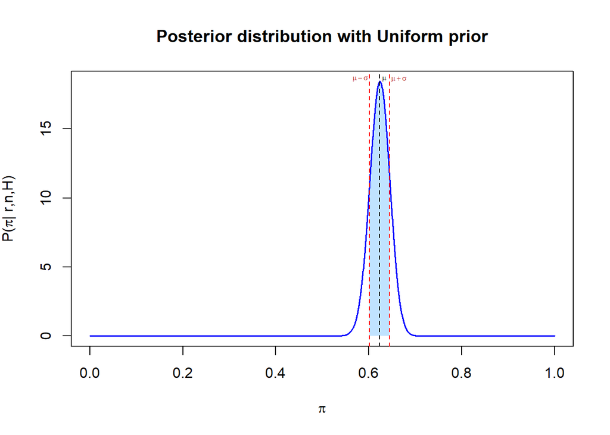

```r
unif_posterior <- function(p){
  alpha <- r+1
  beta <- n-r+1
  return(list(y=dbeta(p, alpha, beta), mean=alpha/(alpha+beta), var=(alpha*beta)/((alpha+beta)^2 * (alpha+beta+1))))
}

plot_dist(unif_posterior)
title(main='Posterior distribution with Uniform prior')
```

##### Jeffrey’s prior

The prior is in this case $P(\pi|H) \thicksim Beta(1/2, 1/2)$, so that the posterior pdf is

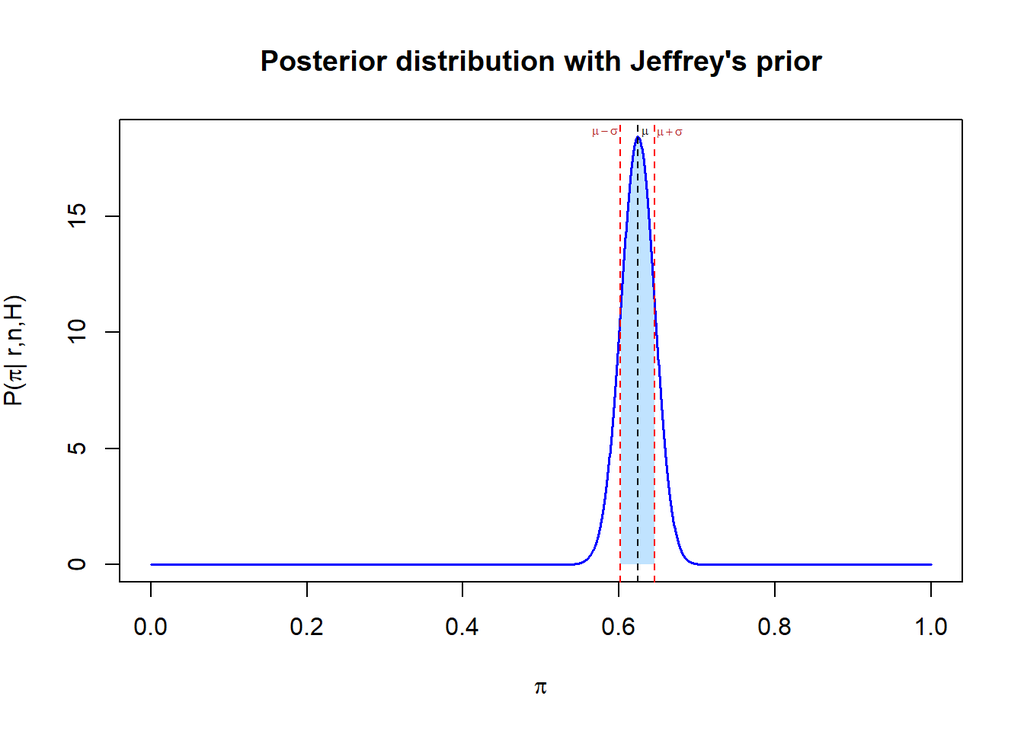

```r
jeffrey_posterior <- function(p){
  alpha <- r+0.5
  beta <- n-r+0.5
  return(list(y=dbeta(p, alpha, beta), mean=alpha/(alpha+beta), var=(alpha*beta)/((alpha+beta)^2 * (alpha+beta+1))))
}

plot_dist(jeffrey_posterior)
title(main="Posterior distribution with Jeffrey's prior")
```

#### (c) Mean, variance and posterior distributions of researcher B

Assuming a uniform prior with the results of researcher B, that is with $n=10$, $r=10$, we get the posterior

$$P(\pi | r,n,H) = Beta(r+1, n-r+1) = Beta(11, 1) \\$$

It can be inferred that the mean and variance are

$$E[\pi] = \frac{11}{12} \approx 0.9167 \quad \text{and} \quad Var(\pi) =
\frac{11\cdot 1}{12^2 \cdot 13} \approx 0.0059$$

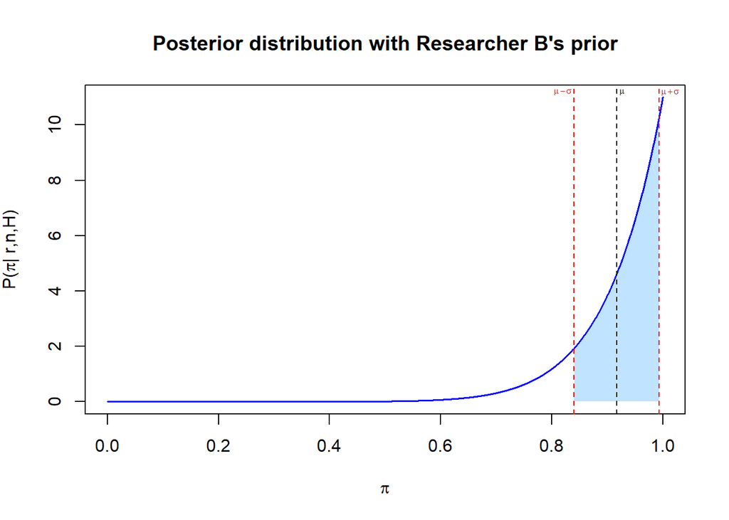

```r
B_posterior <- function(p){
  alpha <- 11
  beta <- 1
  return(list(y=dbeta(p, alpha, beta), mean=alpha/(alpha+beta), var=(alpha*beta)/((alpha+beta)^2 * (alpha+beta+1))))
}

plot_dist(B_posterior)
title(main="Posterior distribution with Researcher B's prior")
```

#### (d) Mean, variance and posterior distributions from the new prior

The posterior obtained from point (c) is assumed as the new Beta prior, so that $P(\pi|H) = 11\pi^{10} = Beta(11,1)$. The new posterior pdf is then obtained by multiplying it by the likelihood, as in the following. The experimental data are once again $n=500$, $r=312$.

$$P(\pi | r,n,H) = Beta(323, 189) \qquad E[\pi] = \frac{323}{512} \approx
0.63086 \qquad Var(\pi) = \frac{323 \cdot 189}{512^2 \cdot 513} \approx
0.00045$$

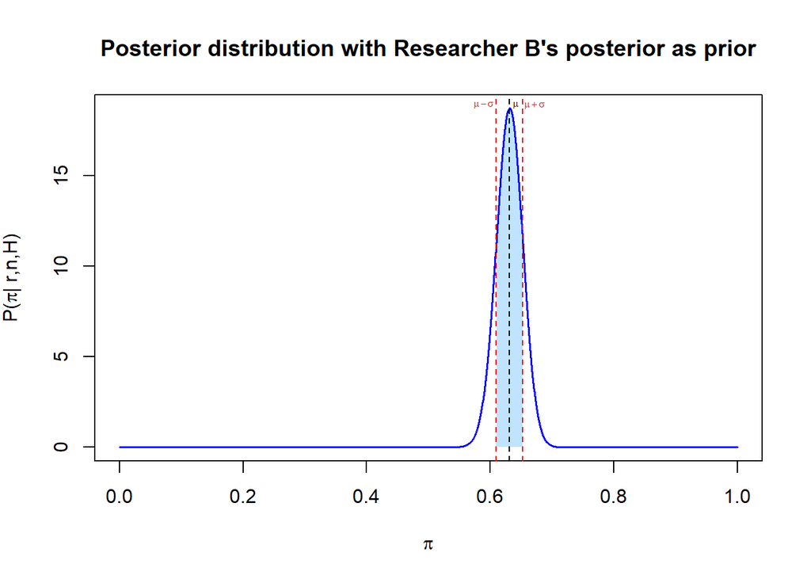

```r
new_posterior <- function(p){
  alpha <- 323
  beta <- 189
  return(list(y=dbeta(p, alpha, beta), mean=alpha/(alpha+beta), var=(alpha*beta)/((alpha+beta)^2 * (alpha+beta+1))))
}

plot_dist(new_posterior)
title(main="Posterior distribution with Researcher B's posterior as prior")
```

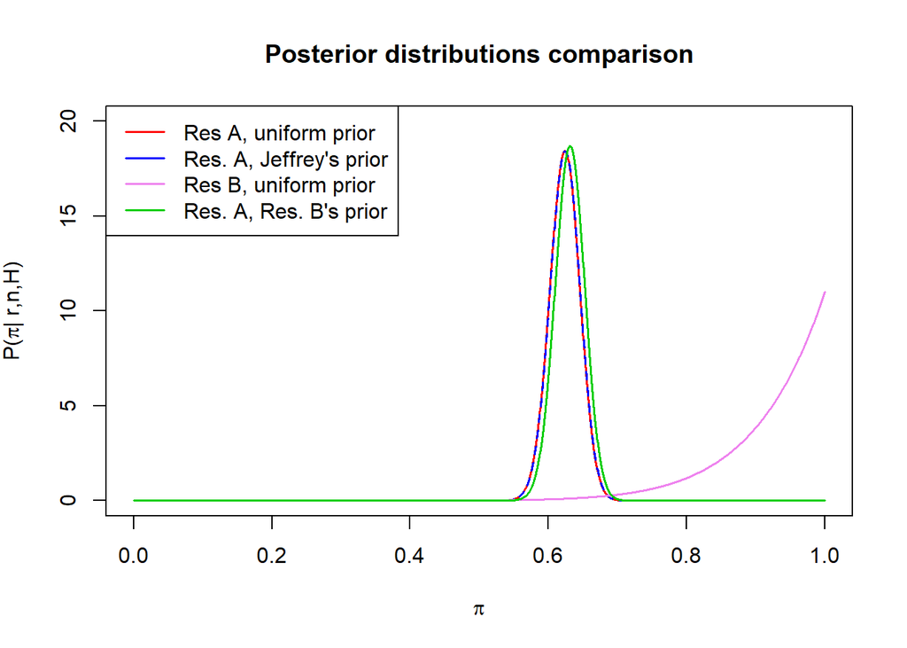

```r
p <- seq(0, 1, 1/n.sample)

plot(p, p, col='white', xlim=c(0,1), ylim=c(0, 20), xlab=expression(pi), ylab=expression(paste('P(', pi, '| r,n,H)')), main='Posterior distributions comparison')

colors <- c('red', 'blue', 'violet', 'green3')
labels <- c('Res A, uniform prior', "Res. A, Jeffrey's prior", 'Res B, uniform prior', "Res. A, Res. B's prior")
ltypes <- c(1, 2, 1, 1)
dist_functions <- list(unif_posterior, jeffrey_posterior, B_posterior, new_posterior)

for (i in 1:4){
  posterior <- lapply(p, dist_functions[[i]])
  y_values <- sapply(posterior, function(p) p$y)
  lines(p, y_values, lwd=1.5, col=colors[i], lty=ltypes[i])
}

legend('topleft', col=colors, legend=labels, lwd=1.5, lty=ltypes[i])
```

#### (e) 95% crediblity interval

From the given posterior

$$P(\pi | r,n,H) = \frac{1}{B(323, 189)} \pi^{322} (1-\pi)^{188}$$

a credibility interval $[a,b]$ amounting to the 95% of the total integral can be derived by solving (numerically!) the equations below.

$$0.025 = \frac{1}{B(323, 189)} \int^{a}_{0} \pi^{322} (1-\pi)^{188}
d\pi\\
\text{and} \\
0.975 = \frac{1}{B(323, 189)} \int^{b}_{0} \pi^{322} (1-\pi)^{188} d\pi$$

```r
new_posterior_cred <- function(p){
  alpha <- 323
  beta <- 189
  return(dbeta(p, alpha, beta))
}

plot_cred_int <- function(dist_function) {

  p <- seq(0, 1, 1/n.sample)

  y_values <- sapply(p, dist_function)

  # Define the integral function from 0 to a
  integral_to_a <- function(a) {
    integrate(dist_function, lower = 0, upper = a)$value
  }

  # Define the function to solve the equation
  find_a <- function(target) {
    to_solve <- function(a) {
      integral_to_a(a) - target
    }

    # Use uniroot to find the root in a reasonable interval
    result <- uniroot(to_solve, lower = 0, upper = 1)
    return(result$root)
  }

  # Find a such that the integral equals 0.025
  a_value <- find_a(0.025)
  b_value <- find_a(0.975)

  cat("The 95% credibility interval is [", a_value, ",", b_value, "].\n")

  p_red <- p[p >= a_value & p <= b_value]
  y_red <- y_values[p >= a_value & p <= b_value]

  plot(p, p, col='white', xlim=c(0,1), ylim=c(0, max(y_values)), xlab=expression(pi), ylab=expression(paste('P(', pi, '| r,n,H)')))
  polygon(c(a_value, a_value, p_red, b_value, b_value), c(0, 0.38, y_red, 0.3, 0), col = rgb(130/255, 200/255, 255/255, 0.5), border = NA)

  lines(p, y_values, lwd=1.5, col='blue')

  abline(v=a_value, lty=2, col='red')
  abline(v=b_value, lty=2, col='red')
}

plot_cred_int(new_posterior_cred)
```

```
## The 95% credibility interval is [ 0.5886383 , 0.6721367 ].
```

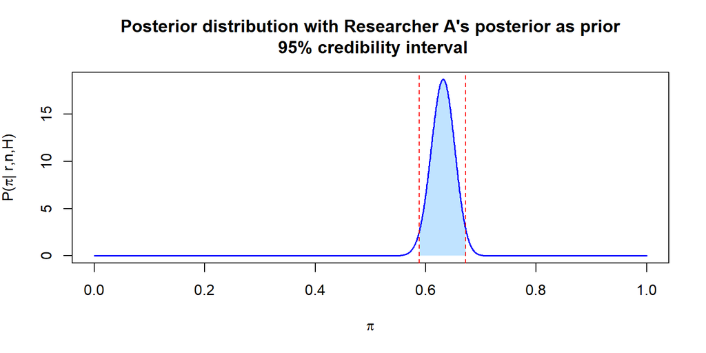

```r
title(main="Posterior distribution with Researcher A's posterior as prior\n 95% credibility interval")
```

## Exercise 3 - Bayesian Inference for Binomial model

A coin is flipped $n = 30$ times with the following outcomes:

$T, T, T, T, T, H, T, T, H, H, T, T, H, H, H, T, H, T, H, T, H, H, T, H, T, H, T, H, H, H$

1. Assuming a flat prior, and a beta prior, plot the likelihood, prior and posterior distributions for the data set.
2. Evaluate the most probable value for the coin probability p and, integrating the posterior probability distribution, give an estimate for a 95% credibility interval.
3. Repeat the same analysis assuming a sequential analysis of the data. Show how the most probable value and the credibility interval change as a function of the number of coin tosses (i.e. from 1 to 30).
4. Do you get a different result, by analyzing the data sequentially with respect to a one-step analysis (i.e. considering all the data as a whole)?

### Solution

#### (a) Likelihood, prior and posterior distributions

Assuming that the desired outcome of the coin tossing is tails, we get $n=30$ and $r=15$. Two different priors are considered, a uniform prior $Beta(1, 1)$ and a Beta prior $Beta(\alpha, \beta)$, yielding the following posteriors.

$$P_{unif}(\pi | r,n,H) = Beta(r+1, n-r+1) = Beta(16, 16)\\
P_{beta}(\pi | r,n,H) = Beta(r+\alpha, n-r+\beta) = Beta(15 + \alpha, 15
+ \beta)$$

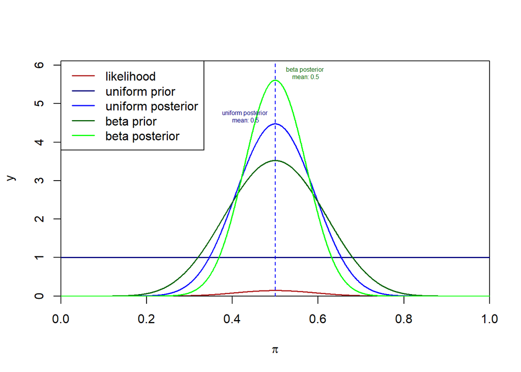

```r
n <- 30
r <- 15
# different values for alpha and beta yield different results for the prior and posterior distributions
alpha <- 10
beta <- 10

likelihood <- function(x) {
  return(choose(n,r) * x^r * (1-x)^{n-r})
}

unif_prior <- function(x) {
  return(dbeta(x, 1, 1))
}

beta_prior <- function(x) {
  return(dbeta(x, alpha, beta))
}

unif_posterior <- function(x) {
  return(dbeta(x, 16, 16))
}

beta_posterior <- function(x) {
  return(dbeta(x, 15+alpha, 15+beta))
}

n.sample <- 2000
delta.p <- 1/n.sample

p <- seq(from=1/(2*n.sample), by=1/n.sample , length.out=n.sample)
y_likelihood <- sapply(p, likelihood)
y_unifprior <- sapply(p, unif_prior)
y_betaprior <- sapply(p, beta_prior)
y_unifpost <- sapply(p, unif_posterior)
y_betapost <- sapply(p, beta_posterior)

max_value <- max(y_likelihood, y_unifpost, y_unifprior, y_betapost, y_betaprior)

plot(p, y_likelihood , type="l", lwd=1.5, col='firebrick', xlim=c(0,1), ylim=c(0,max_value+0.5), xaxs="i", yaxs="i", xlab=expression(pi), ylab='y')
lines(p, y_unifprior , type="l", lwd=1.5, col='navy')
lines(p, y_unifpost , type="l", lwd=1.5, col='blue')
lines(p, y_betaprior , type="l", lwd=1.5, col='darkgreen')
lines(p, y_betapost , type="l", lwd=1.5, col='green')
legend("topleft", legend=c("likelihood", "uniform prior", "uniform posterior", "beta prior", "beta posterior"), col=c("firebrick", "navy", "blue", "darkgreen", "green"), lwd=1.5)

p.mean.b <- delta.p*sum(p*y_betapost)
p.mean.u <- delta.p*sum(p*y_unifpost)
abline(v=p.mean.b, col='green',lty=2)
abline(v=p.mean.u, col='blue',lty=2)
text(x = p.mean.b + 0.07, y = max(y_betapost) + 0.2, labels = paste('beta posterior\n mean:', round(p.mean.b, 3)), col = "darkgreen", cex = 0.5)
text(x = p.mean.u - 0.07, y = max(y_unifpost) + 0.2, labels = paste('uniform posterior\n mean:', round(p.mean.u, 3)), col = "navy", cex = 0.5)
```

#### (b) Most probable value for $p$ and 95% crediblity interval

In order to compute the desired credibility interval, a numerical method can be employed, as in the previous Exercise 2(e).

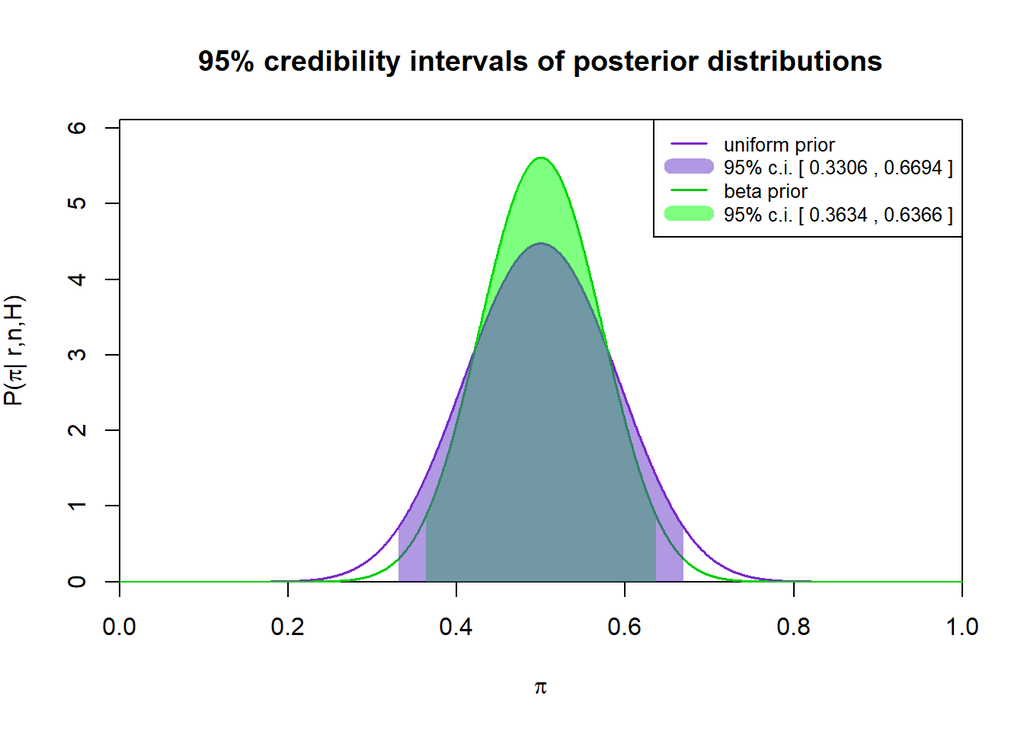

```r
unif_integral_to_a <- function(a) {
  integrate(unif_posterior, lower = 0, upper = a)$value
}

beta_integral_to_a <- function(a) {
  integrate(beta_posterior, lower = 0, upper = a)$value
}


unif_find_a <- function(target) {
  to_solve <- function(a) {
    unif_integral_to_a(a) - target
  }
  result <- uniroot(to_solve, lower = 0, upper = 1)
  return(result$root)
}

beta_find_a <- function(target) {
  to_solve <- function(a) {
    beta_integral_to_a(a) - target
  }
  result <- uniroot(to_solve, lower = 0, upper = 1)
  return(result$root)
}

a_unif <- unif_find_a(0.025)
b_unif <- unif_find_a(0.975)
a_beta <- beta_find_a(0.025)
b_beta <- beta_find_a(0.975)

n.sample <- 2000
delta.p <- 1/n.sample

p <- seq(from=1/(2*n.sample), by=1/n.sample , length.out=n.sample)
y_unifpost <- sapply(p, unif_posterior)
y_betapost <- sapply(p, beta_posterior)

plot(p, y_unifpost , type="l", lwd=1.5, col='purple3', xlim=c(0,1), ylim=c(0,max(c(y_unifpost, y_betapost))+0.5), xaxs="i", yaxs="i", xlab=expression(pi), ylab=expression(paste('P(', pi, '| r,n,H)')))
lines(p, y_betapost , type="l", lwd=1.5, col='green3')

x_red_b <- p[p >= a_beta & p <= b_beta]
y_red_b <- y_betapost[p >= a_beta & p <= b_beta]
polygon(c(a_beta, a_beta, x_red_b, b_beta, b_beta), c(0, 0.12, y_red_b, 0.09, 0), col = rgb(0/255, 255/255, 0/255, 0.5), border = NA)

x_red_u <- p[p >= a_unif & p <= b_unif]
y_red_u <- y_unifpost[p >= a_unif & p <= b_unif]
polygon(c(a_unif, a_unif, x_red_u, b_unif, b_unif), c(0, 0.12, y_red_u, 0.09, 0), col = rgb(100/255, 50/255, 200/255, 0.5), border = NA)

legend("topright",
       legend=c("uniform prior", paste("95% c.i. [", signif(a_unif, 4), ",", signif(b_unif,4), "]"), "beta prior",  paste("95% c.i. [", signif(a_beta, 4), ",", signif(b_beta,4), "]")),
       col=c("purple3", rgb(100/255, 50/255, 200/255, 0.5), "green3", rgb(0/255, 255/255, 0/255, 0.5)),
       lwd=c(1.5, 10, 1.5, 10), cex=0.8
       )
title(main="95% credibility intervals of posterior distributions")
```

#### (c) Sequential analysis of the data.

```r
tosses <- c('T', 'T', 'T', 'T', 'T', 'H', 'T', 'T', 'H', 'H', 'T', 'T', 'H', 'H', 'H', 'T', 'H', 'T', 'H', 'T', 'H', 'H', 'T', 'H', 'T', 'H', 'T', 'H', 'H', 'H')
binary_tosses <- ifelse(tosses == 'T', 1, 0)

n_seq <- c(1:length(tosses))
r_seq <- cumsum(binary_tosses)

n.sample <- 2000
delta.p <- 1/n.sample
p <- seq(from=1/(2*n.sample), by=1/n.sample , length.out=n.sample)

mean_values_unif <- numeric(length(tosses))
ci_upper_unif <- numeric(length(tosses))
ci_lower_unif <- numeric(length(tosses))

mean_values_beta <- numeric(length(tosses))
ci_upper_beta <- numeric(length(tosses))
ci_lower_beta <- numeric(length(tosses))

for (n in n_seq) {
  r <- r_seq[n]

  unif_posterior <- function(p) {
    return(dbeta(p, r+1, n-r+1))
  }

  beta_posterior <- function(p) {
    return(dbeta(p, r+alpha, n-r+beta))
  }

  unif_integral_to_a <- function(a) {
    integrate(unif_posterior, lower = 0, upper = a)$value
  }

  beta_integral_to_a <- function(a) {
    integrate(beta_posterior, lower = 0, upper = a)$value
  }


  unif_find_a <- function(target) {
    to_solve <- function(a) {
      unif_integral_to_a(a) - target
    }
    result <- uniroot(to_solve, lower = 0, upper = 1)
    return(result$root)
  }

  beta_find_a <- function(target) {
    to_solve <- function(a) {
      beta_integral_to_a(a) - target
    }
    result <- uniroot(to_solve, lower = 0, upper = 1)
    return(result$root)
  }

  ci_lower_unif[n] <- unif_find_a(0.025)
  ci_upper_unif[n] <- unif_find_a(0.975)
  ci_lower_beta[n] <- beta_find_a(0.025)
  ci_upper_beta[n] <- beta_find_a(0.975)

  mean_values_beta[n] <- (r+1)/(n+2)
  mean_values_unif[n] <- (r+alpha)/(n+alpha+beta)
}
```

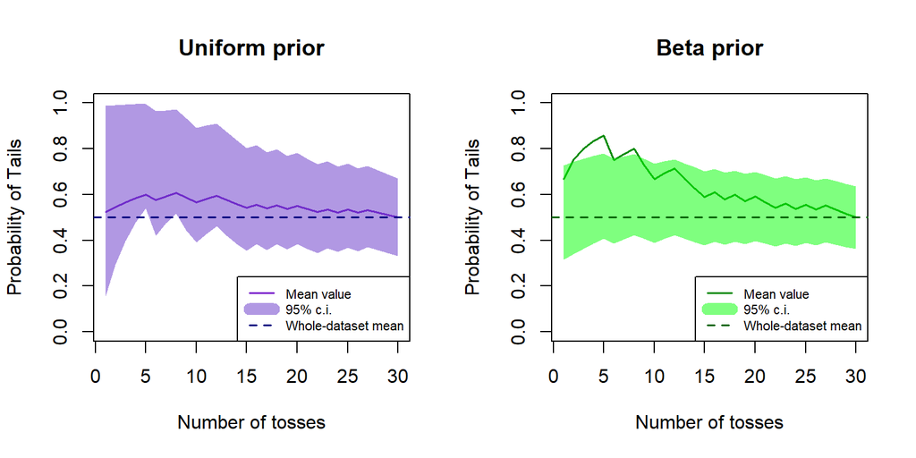

```r
par(mfrow=c(1, 2))

plot(n_seq, mean_values_unif, type='l', col='purple3', lwd=1.5, ylim=c(0,1), lty=1, xlab='Number of tosses', ylab='Probability of Tails', main='Uniform prior')
polygon(c(n_seq, rev(n_seq)), c(ci_upper_unif, rev(ci_lower_unif)), col=rgb(100/255, 50/255, 200/255, 0.5), border=FALSE)
abline(h=p.mean.u, col='navy', lty=2, lwd=1.5)
legend('bottomright', legend=c('Mean value', '95% c.i.', 'Whole-dataset mean'), col=c('purple3', rgb(100/255, 50/255, 200/255, 0.5), 'navy'), lwd=c(1.5, 10, 1.5), cex=0.7, lty=c(1,1,2))


plot(n_seq, mean_values_beta, type='l', col='green4', lwd=1.5, ylim=c(0,1), lty=1, xlab='Number of tosses', ylab='Probability of Tails', main='Beta prior')
polygon(c(n_seq, rev(n_seq)), c(ci_upper_beta, rev(ci_lower_beta)), col=rgb(0/255, 255/255, 0/255, 0.5), border=FALSE)
abline(h=p.mean.b, col='darkgreen', lty=2, lwd=1.5)
legend('bottomright', legend=c('Mean value', '95% c.i.', 'Whole-dataset mean'), col=c('green4', rgb(0/255, 255/255, 0/255, 0.5), 'darkgreen'), lwd=c(1.5, 10, 1.5), cex=0.7, lty=c(1,1,2))
```

#### (d)

It can be observed by the previous plot that a sequential analysis gives the same result with respect to a whole-dataset analysis.

## Exercise 4 - Poll

A couple of days before an election in which four parties (A,B,C,D) compete, a poll is taken using a sample of 200 voters who express the following preferences 57, 31, 45 and 67 for, respectively, parties A,B,C and D. Using a Bayesian approach, for all parties

- Calculate the expected percentage of votes and a 68% credibility interval by assuming as prior a
  - uniform prior
  - a prior constructed from the results obtained from another poll conducted the previous week on a sample of 100 voters who expressed the following preferences 32,14,26,28 for, respectively, parties A,B,C and D.
- Sample size to obtain a margin of error less or equal than ±3% for each party

### Solution

#### (a) Expected percentages and credibility intervals

This problem can be modeled by a multinomial distribution, so that labeling the disjoint outcomes $A_1$, $A_2$, $A_3$, $A_4$ (corresponding to a vote for each different party), $P(A_j) = p_j$ is the probability of a vote occurring. Moreover, in this problem there are $n=200$ independent trials, where $n = \sum_{j=1...4} x_j$ and $x_j$ is the number of votes for each party, i.e. $\{x_1, x_2, x_3, x_4 \} =\{57, 31, 45, 67 \}$. We have then a multinomial likelihood, of the type

$$P(X_1=x_1, X_2=x_2, X_3=x_3, X_4=x_4|p_1, p_2, p_3, p_4, n) =
\frac{n!}{x_1!\ x_2!\ x_3!\ x_4!} \ p_1^{x_1}\ p_2^{x_2}\ p_3^{x_3}\
p_4^{x_4}$$
The properties of the multinomial distribution are the following:

$$E[x_j] = n\ p_j \qquad Var(x_j)=n\ p_j\ (1-p_j) \qquad Cov(x_i, x_j) =
-n\ p_i\ p_j$$
and moreover, when n becomes large, the distribution tends to a multinormal distribution.

##### Uniform prior

Taking into account the experimental data and a uniform prior, i.e. $\{p_j\}_{j=1...4}=\{\frac{1}{4}, \frac{1}{4}, \frac{1}{4}, \frac{1}{4} \}$, the posterior is a 4-dimensional Beta distribution where for each variable we take $Beta(r+\alpha, n-r+\beta) = Beta(r+1, 200-r+1)$, $r \in \{x_j\}$.

```r
plot_ex4 <- function(xjs, alpha, beta){
  y <- list()
  means <- numeric(length(xjs))
  cis <- list()
  cf <- 0.68
  p_reds <- list()
  y_reds <- list()
  n <- sum(xjs)

  for (i in 1:length(xjs)){
    y[[i]] <- dbeta(p, xjs[i]+alpha, n-xjs[i]+beta)
    means[i] <- (xjs[i]+alpha)/(n+alpha+beta)
    cis[[i]] <- qbeta(c((1-cf)/2, cf + (1-cf)/2), xjs[i]+alpha, n-xjs[i]+beta)
    p_reds[[i]] <- p[p>=cis[[i]][1] & p<=cis[[i]][2]]
    y_reds[[i]] <- y[[i]][p>=cis[[i]][1] & p<=cis[[i]][2]]
  }

  max_value <- max(y[[2]])+0.5

  colors <- c(rgb(255/255, 130/255, 171/255, 0.5), 'red3', 'darkred', rgb(130/255, 200/255, 255/255, 0.5), 'blue', 'navy', rgb(100/255, 50/255, 200/255, 0.5), 'purple', 'purple4', rgb(0/255, 255/255, 0/255, 0.5), 'green3', 'darkgreen')

  labels <- c(paste("party A 68% c.i. [", 100*signif(cis[[1]][1], 3), ',', 100*signif(cis[[1]][2], 3), ']'),
              "party A posterior", paste("party A mean", 100*signif(means[1], 3)),
              paste("party B 68% c.i. [", 100*signif(cis[[2]][1], 3), ',', 100*signif(cis[[2]][2], 3), ']'),
              "party B posterior", paste("party B mean", 100*signif(means[2], 3)),
              paste("party C 68% c.i. [", 100*signif(cis[[3]][1], 3), ',', 100*signif(cis[[3]][2], 3), ']'),
              "party C posterior", paste("party C mean", 100*signif(means[3], 3)),
              paste("party D 68% c.i. [", 100*signif(cis[[4]][1], 3), ',', 100*signif(cis[[4]][2], 3), ']'),
              "party D posterior", paste("party D mean", 100*signif(means[4], 3)))
  lwds <- c(rep(c(10, 1.5, 1.5), 4))
  ltys <- c(rep(c(1, 1, 2), 4))

  plot(p, p, type="l", lwd=1.5, col='white', xlim=c(0,100), ylim=c(0,max_value), xaxs="i", yaxs="i", xlab='Expected percentage of votes', ylab=expression(paste('Posterior pdf')))

  for (i in 1:length(xjs)){
    polygon(100*c(cis[[i]][1], p_reds[[i]], cis[[i]][2]), c(0, y_reds[[i]], 0), col=colors[1+(length(xjs)-1)*(i-1)], border=FALSE)
    lines(100*p, y[[i]] , type="l", lwd=1.5, col=colors[2+(length(xjs)-1)*(i-1)], lty=1)
    abline(v=100*means[i], lty=2, col=colors[3+(length(xjs)-1)*(i-1)], lwd=1.5)
  }

  legend("topright", legend=labels, col=colors, lwd=lwds, lty=ltys, cex=0.8)
  return(list(y, means, cis))
}
```

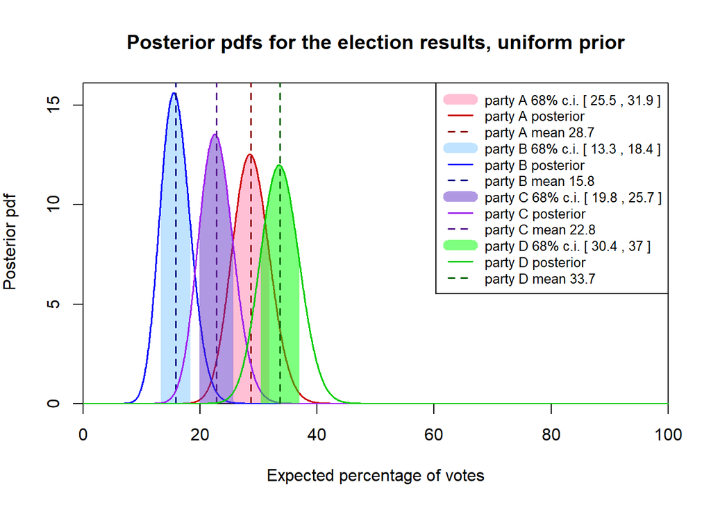

```r
xjs <- c(57, 31, 45, 67)

alpha <- 1
beta <- 1

n.sample <- 2000
delta.p <- 1/n.sample

p <- seq(from=1/(2*n.sample), by=1/n.sample , length.out=n.sample)

unif_data <- plot_ex4(xjs, alpha, beta)
title(main='Posterior pdfs for the election results, uniform prior')
```

##### Custom prior

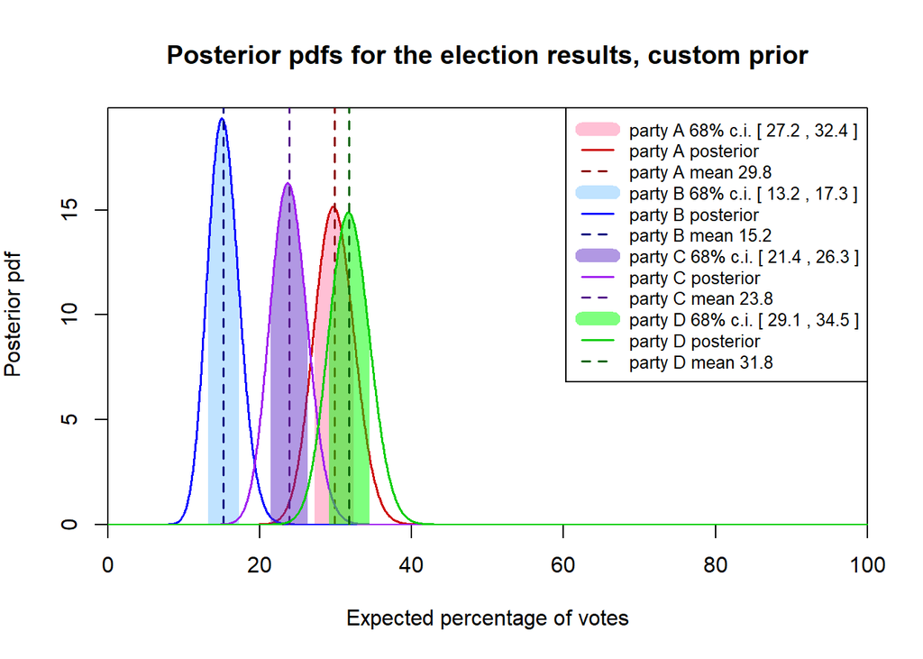

```r
xjs_prev <- c(32, 14, 26, 28)

custom_data <- plot_ex4(xjs + xjs_prev, alpha, beta)
title(main='Posterior pdfs for the election results, custom prior')
```

#### (b) Sample size to obtain a margin of error less or equal than ±3% for each party

For a sample proportion $p$ with sample size $n$, the margin of error can be calculated as $m.o.e. = \frac{1}{Z} \sqrt{\frac{p(1-p)}{n}}$ where $Z$ is the Z-score corresponding to the desired confidence level, in this case 68% for which $Z \approx 1$. Indeed, $n \geq \frac{p(1-p)}{0.03^2}$. Inserting in this equation the 4 possible values for p, obtained as $E[p]$ from the previous analysis, one gets the following.

```r
n_unif <- ceiling(max(unif_data[[2]]*(1-unif_data[[2]])/(0.03^2)))
n_cust <- ceiling(max(custom_data[[2]]*(1-custom_data[[2]])/(0.03^2)))

print(paste('The necessary sample size to obtain a margin of error less or equal than ±3% for each party is', n_unif, 'with the uniform prior and', n_cust, 'with the custom beta prior.'))
```

```
## [1] "The necessary sample size to obtain a margin of error less or equal than ±3% for each party is 249 with the uniform prior and 241 with the custom beta prior."
```